# nla2012_waterchem

Bryan Milstead

13 July 2017

## To Do

- insult of the day: thou froward dread-bolted baggage

## Naming Conventions

- All variable names in lowercase
- use snake case for compound names (e.g., big_data)
- use parameter for the variable (e.g., NTL)
- use value for the measured value of the parameter

## Introduction

- This document ([nla2012_waterchem](https://github.com/willbmisled/lakes_database/blob/master/R/nla2012_waterchem.Rmd)) describes converting the water chemistry data for the 2012 National Lakes Assessment from the wide format of the raw data files to a long format for database development. For more information see [nla2012_master.rmd](https://github.com/willbmisled/lakes_database/blob/master/R/nla2012_master.Rmd).
- The output includes the following NLA 2012 datasets
  - waterchem
  - chla
  - algal toxins
  - atrazine
  - secchi
  - profile (partial: only the DO2_2M and temperature data are included)
- Four of these datasets (waterchem, chla, algal toxins, and atrazine) were processed in the same way:
  - The original raw data files are in a wide format with two types of column names:
    - sample specific data: this includes things such as the UID (unique identifier for the sample), the LAB where the data were processed, and sample_ID.
    - parameter specific data: the names are complex variables indicating the a chemical parameter (e.g. COND=conductivity) and what is reported (e.g RESULT, UNITS, BATCH_ID, etc.).
  - Not all of these data are useful to us but we will keep most of them just in case. The final product may be pruned.
  - To support the conversion to a long format data structure files were created manually as csv files. The structure files define which columns are “sample specic”, which are “parameter specific” and which should be deleted. They will be used to convert the paramater specific data to a long format while the sample specific data are kept in the wide format. Confusing?
- The final two datasets secchi and profile deal with single parameters (secchi and DO2_2M). See details below

## Data Steps

- a function “formatData” was written to:
  - import the data and the structure file
  - reformat the data to a long format
- each dataset is reformatted and the general structure is defined
- datasets were combined into a single data.frame
- rearrange
- rename
- snake_case

### waterchem data

- The following table shows how the raw data will be deconstructed:
  - DATA_COLUMN: represents the original columns in the raw data
  - parameter: in most cases this will be the parameter name in the new dataset except:
    - parameter==“column_name” indicates this column is sample specific so all unique observations will be kept
    - parameter==“delete” indicates this column will be deleted from the final data

| DATA_COLUMN | parameter | column_name | description |
| --- | --- | --- | --- |
| UID | column_name | uid | Unique site visit ID |
| LAB | column_name | lab | Lab name |
| CHEM_SAMPLE_ID | column_name | chem_sample_id | Chemistry Sample ID |
| CHEM_SHIP_FLAG | column_name | chem_ship_flag | Chemistry Shipping Flag |
| NUTS_SAMPLE_ID | column_name | nuts_sample_id | Nutrients Sample ID |
| NUTS_SHIP_FLAG | column_name | nuts_ship_flag | Nutrients Shipping Flag |
| SAM_CODE | delete | NA | NOTE: not in nla2012_waterchem_meta.csv; only used for waterchem data; all values=“REGULAR”; delete |
| ALUMINUM_BATCH_ID | aluminum | batch_id | Batch ID from lab for Aluminum |
| ALUMINUM_DATE_ANALYZED | aluminum | date_analyzed | Date of sample analysis for Aluminum |
| ALUMINUM_HOLDING_TIME | aluminum | ht | Sample holding time for Aluminum |
| ALUMINUM_LAB_FLAG | aluminum | lab_flag | Flag from laboratory for Aluminum |
| ALUMINUM_LAB_SAMPLE_ID | aluminum | lab_sample_id | Laboratory Sample ID for Aluminum |
| ALUMINUM_MDL | aluminum | mdl | Minimum detection limit of analyte for Aluminum |
| ALUMINUM_QA_FLAG | aluminum | qa_flag | QA flag associated with sample for Aluminum |
| ALUMINUM_RESULT | aluminum | result | Analyte value for Aluminum |
| ALUMINUM_RL | aluminum | rl | Reporting limit for Aluminum |
| ALUMINUM_UNITS | aluminum | units | Units for Aluminum |
| AMMONIA_N_BATCH_ID | ammonia_n | batch_id | Batch ID from lab for Ammonia as N |
| AMMONIA_N_DATE_ANALYZED | ammonia_n | date_analyzed | Date of sample analysis for Ammonia as N |
| AMMONIA_N_HOLDING_TIME | ammonia_n | ht | Sample holding time for Ammonia as N |
| AMMONIA_N_LAB_FLAG | ammonia_n | lab_flag | Flag from laboratory for Ammonia as N |
| AMMONIA_N_LAB_SAMPLE_ID | ammonia_n | lab_sample_id | Laboratory Sample ID for Ammonia as N |
| AMMONIA_N_MDL | ammonia_n | mdl | Minimum detection limit of analyte for Ammonia as N |
| AMMONIA_N_QA_FLAG | ammonia_n | qa_flag | QA flag associated with sample for Ammonia as N |
| AMMONIA_N_RESULT | ammonia_n | result | Analyte value for Ammonia as N |
| AMMONIA_N_RL | ammonia_n | rl | Reporting limit for Ammonia as N |
| AMMONIA_N_UNITS | ammonia_n | units | Units for Ammonia as N |
| ANC_BATCH_ID | anc | batch_id | Batch ID from lab for Acid Neutralizing Capacity |
| ANC_DATE_ANALYZED | anc | date_analyzed | Date of sample analysis for Acid Neutralizing Capacity |
| ANC_FLAG | anc | flag | Flag for Acid Neutralizing Capacity |

[output cut: 203 more lines]

- The waterchm dataset has the following columns (NOTE: some of these may be dropped or renamed in the final dataset):

```
##  [1] "batch_id"       "chem_sample_id" "chem_ship_flag" "date_analyzed"
##  [5] "flag"           "ht"             "lab"            "lab_flag"
##  [9] "lab_sample_id"  "mdl"            "nuts_sample_id" "nuts_ship_flag"
## [13] "parameter"      "qa_flag"        "result"         "rl"
## [17] "source"         "uid"            "units"
```

- The following parameters are included as rows in the final dataset (NOTE: some of these may be dropped or renamed in the final dataset):

```
##  [1] "aluminum"          "ammonia_n"         "anc"
##  [4] "calcium"           "chloride"          "color"
##  [7] "cond"              "doc"               "magnesium"
## [10] "nitrate_n"         "nitrate_nitrite_n" "nitrite_n"
## [13] "ntl"               "ph"                "potassium"
## [16] "ptl"               "silica"            "sodium"
## [19] "sulfate"           "toc"               "tss"
## [22] "turb"
```

### chla

- Chlorophyll was measured in the littoral zone (CHLL) and the deep spot (CHLX) these parameters were renamed:
  - CHLL = ‘chla_littoral’
  - CHLX = ‘chla’
- The following table shows how the raw data will be deconstructed:
  - DATA_COLUMN: represents the original columns in the raw data
  - parameter: in most cases this will be the parameter name in the new dataset except:
    - parameter==“column_name” indicates this column is sample specific so all unique observations will be kept
    - parameter==“delete” indicates this column will be deleted from the final data

| DATA_COLUMN | parameter | column_name | LABEL |
| --- | --- | --- | --- |
| UID | column_name | uid | Unique site visit ID |
| LAB | column_name | lab | Lab name |
| CHLL_BATCH_ID | chla_littoral | batch_id | Batch ID from lab for Littoral chlorophyll a |
| CHLL_DATE_ANALYZED | chla_littoral | date_analyzed | Date of sample analysis for Littoral chlorophyll a |
| CHLL_DATE_FILTERED | chla_littoral | date_filtered | Date sample filtered for Littoral chlorophyll a |
| CHLL_DILUTION_FACTOR | chla_littoral | dilution_factor | Dilution factor used in chlorophyll calculation for Littoral chlorophyll a |
| CHLL_EXTRACT | chla_littoral | extract | Chlorophyll a in laboratory extract (raw) for Littoral chlorophyll a |
| CHLL_HOLDING_TIME | chla_littoral | ht | Sample holding time for Littoral chlorophyll a |
| CHLL_LAB_COMMENT | chla_littoral | lab_comment | Laboratory comment for Littoral chlorophyll a |
| CHLL_LAB_FLAG | chla_littoral | lab_flag | Flag from laboratory for Littoral chlorophyll a |
| CHLL_LAB_SAMPLE_ID | chla_littoral | lab_sample_id | Laboratory Sample ID for Littoral chlorophyll a |
| CHLL_MDL | chla_littoral | mdl | Minimum detection limit of analyte for Littoral chlorophyll a |
| CHLL_QA_FLAG | chla_littoral | qa_flag | QA flag associated with sample for Littoral chlorophyll a |
| CHLL_RESULT | chla_littoral | result | Analyte value for Littoral chlorophyll a |
| CHLL_RL | chla_littoral | rl | Reporting limit for Littoral chlorophyll a |
| CHLL_SAMPLEVOL | chla_littoral | samplevol | Volume of sample from field for Littoral chlorophyll a |
| CHLL_UNITS | chla_littoral | units | Units for Littoral chlorophyll a |
| CHLL_VOLUME_ADJUST | chla_littoral | volume_adjust | Sample volume adjustment (for calculation) for Littoral chlorophyll a |
| CHLX_BATCH_ID | chla | batch_id | Batch ID from lab for X-site chlorophyll a |
| CHLX_DATE_ANALYZED | chla | date_analyzed | Date of sample analysis for X-site chlorophyll a |
| CHLX_DATE_FILTERED | chla | date_filtered | Date sample filtered for X-site chlorophyll a |
| CHLX_DILUTION_FACTOR | chla | dilution_factor | Dilution factor used in chlorophyll calculation for X-site chlorophyll a |
| CHLX_EXTRACT | chla | extract | Chlorophyll a in laboratory extract (raw) for X-site chlorophyll a |
| CHLX_HOLDING_TIME | chla | ht | Sample holding time for X-site chlorophyll a |
| CHLX_LAB_COMMENT | chla | lab_comment | Laboratory comment for X-site chlorophyll a |
| CHLX_LAB_FLAG | chla | lab_flag | Flag from laboratory for X-site chlorophyll a |
| CHLX_LAB_SAMPLE_ID | chla | lab_sample_id | Laboratory Sample ID for X-site chlorophyll a |
| CHLX_MDL | chla | mdl | Minimum detection limit of analyte for X-site chlorophyll a |
| CHLX_QA_FLAG | chla | qa_flag | QA flag associated with sample for X-site chlorophyll a |
| CHLX_RESULT | chla | result | Analyte value for X-site chlorophyll a |
| CHLX_RL | chla | rl | Reporting limit for X-site chlorophyll a |
| CHLX_SAMPLEVOL | chla | samplevol | Volume of sample from field for X-site chlorophyll a |
| CHLX_UNITS | chla | units | Units for X-site chlorophyll a |
| CHLX_VOLUME_ADJUST | chla | volume_adjust | Sample volume adjustment (for calculation) for X-site chlorophyll a |

- The chla dataset has the following columns (NOTE: some of these may be dropped or renamed in the final dataset):

```
##  [1] "batch_id"        "date_analyzed"   "date_filtered"
##  [4] "dilution_factor" "extract"         "ht"
##  [7] "lab"             "lab_comment"     "lab_flag"
## [10] "lab_sample_id"   "mdl"             "parameter"
## [13] "qa_flag"         "result"          "rl"
## [16] "samplevol"       "source"          "uid"
## [19] "units"           "volume_adjust"
```

- The following parameters are included as rows in the final dataset (NOTE: some of these may be dropped or renamed in the final dataset):

```
## [1] "chla_littoral" "chla"
```

### microcystin

- Microcystin was measured in the littoral zone (MICL) and the deep spot (MICX) these parameters will be renamed:
  - MICL = ‘microcystin_littoral’
  - MICX = ‘microcystin’
- The following table shows how the raw data will be deconstructed:
  - DATA_COLUMN: represents the original columns in the raw data
  - parameter: in most cases this will be the parameter name in the new dataset except:
    - parameter==“column_name” indicates this column is sample specific so all unique observations will be kept
    - parameter==“delete” indicates this column will be deleted from the final data

| DATA_COLUMN | parameter | column_name | LABEL |
| --- | --- | --- | --- |
| UID | column_name | uid | Unique site visit ID |
| LAB | column_name | lab | Lab name |
| MICX_BATCH_ID | microcystin | batch_id | Batch ID from lab for X-site Microcystin |
| MICX_DATE_ANALYZED | microcystin | date_analyzed | Date of sample analysis for X-site Microcystin |
| MICX_DATE_RECEIVED | microcystin | date_received | Date sample received by laboratory for X-site Microcystin |
| MICX_FLAG | microcystin | flag | Flag for X-site Microcystin |
| MICX_HOLDING_TIME | microcystin | ht | Sample holding time for X-site Microcystin |
| MICX_MDL | microcystin | mdl | Minimum detection limit of analyte for X-site Microcystin |
| MICX_QA_FLAG | microcystin | qa_flag | QA flag associated with sample for X-site Microcystin |
| MICX_RESULT | microcystin | result | Analyte value for X-site Microcystin |
| MICX_RL | microcystin | rl | Reporting limit for X-site Microcystin |
| MICX_SAMPLE_ID | microcystin | lab_sample_id | ID for sample collected for X-site Microcystin |
| MICX_UNITS | microcystin | units | Units for X-site Microcystin |
| MICL_BATCH_ID | microcystin_littoral | batch_id | Batch ID from lab for Littoral Microcystin |
| MICL_DATE_ANALYZED | microcystin_littoral | date_analyzed | Date of sample analysis for Littoral Microcystin |
| MICL_DATE_RECEIVED | microcystin_littoral | date_received | Date sample received by laboratory for Littoral Microcystin |
| MICL_FLAG | microcystin_littoral | flag | Flag for Littoral Microcystin |
| MICL_HOLDING_TIME | microcystin_littoral | ht | Sample holding time for Littoral Microcystin |
| MICL_MDL | microcystin_littoral | mdl | Minimum detection limit of analyte for Littoral Microcystin |
| MICL_QA_FLAG | microcystin_littoral | qa_flag | QA flag associated with sample for Littoral Microcystin |
| MICL_RESULT | microcystin_littoral | result | Analyte value for Littoral Microcystin |
| MICL_RL | microcystin_littoral | rl | Reporting limit for Littoral Microcystin |
| MICL_SAMPLE_ID | microcystin_littoral | lab_sample_id | ID for sample collected for Littoral Microcystin |
| MICL_UNITS | microcystin_littoral | units | Units for Littoral Microcystin |
| AGGR_ECO3_2015 | delete | NA | NARS 3-level reporting region (2015), based on aggregating AGGR_ECO9_2015 reporting regions |
| AGGR_ECO9_2015 | delete | NA | NARS 9-level reporting region (2015), based on aggregated Omernik Level III ecoregions |
| DATE_COL | delete | NA | Date of sample collection |
| SITE_ID | delete | NA | Identification code for site |
| STATE | delete | NA | State lake is assigned to for sampling in NLA 2012 |
| VISIT_NO | delete | NA | Sequential number of visit to site |
| ECO_BIO | delete | NA | NOTE: not in nla2012_algaltoxins_meta_08192016.csv |
| PUBLICATION_DATE | delete | NA | NOTE: not in nla2012_algaltoxins_meta_08192016.csv |

- The mcl dataset has the following columns (NOTE: some of these may be dropped or renamed in the final dataset):

```
##  [1] "batch_id"      "date_analyzed" "date_received" "flag"
##  [5] "ht"            "lab"           "lab_sample_id" "mdl"
##  [9] "parameter"     "qa_flag"       "result"        "rl"
## [13] "source"        "uid"           "units"
```

- The following parameters are included as rows in the final dataset (NOTE: some of these may be dropped or renamed in the final dataset):

```
## [1] "microcystin"          "microcystin_littoral"
```

### atrazine

- The following table shows how the raw data will be deconstructed:
  - DATA_COLUMN: represents the original columns in the raw data
  - parameter: in most cases this will be the parameter name in the new dataset except:
    - parameter==“column_name” indicates this column is sample specific so all unique observations will be kept
    - parameter==“delete” indicates this column will be deleted from the final data

| oreder | DATA_COLUMN | parameter | column_name | LABEL |
| --- | --- | --- | --- | --- |
| 1 | UID | column_name | uid | Unique site visit ID |
| 2 | LAB | column_name | lab | Lab name |
| 3 | TRIA_SAMPLE_ID | column_name | tria_sample_id | Triazine sample ID |
| 4 | ATRAZINE_BATCH_ID | atrazine | batch_id | Batch ID from lab for Atrazine |
| 4 | ATRAZINE_DATE_ANALYZED | atrazine | date_analyzed | Date sample was processed by lab for Atrazine |
| 4 | ATRAZINE_DATE_RECEIVED | atrazine | date_received | Date sample was received by lab for Atrazine |
| 4 | ATRAZINE_FLAG | atrazine | flag | Flag for Atrazine |
| 4 | ATRAZINE_HOLDING_TIME | atrazine | ht | Time between sampling and lab analysis (days) for Atrazine |
| 4 | ATRAZINE_LOQ | atrazine | loq | Quality information: Limit of Quantitation (LOQ) associated with sample for Atrazine |
| 4 | ATRAZINE_MDL | atrazine | mdl | Quality information: Method Detection Limit (MDL) associated with sample for Atrazine |
| 4 | ATRAZINE_QA_FLAG | atrazine | qa_flag | QA flag for Atrazine |
| 4 | ATRAZINE_RESULT | atrazine | result | Analyte value for Atrazine |
| 4 | ATRAZINE_UNITS | atrazine | units | Units for Atrazine |
| 5 | AGGR_ECO3_2015 | delete | NA | NARS 3-level reporting region (2015), based on aggregating AGGR_ECO9_2015 reporting regions |
| 5 | AGGR_ECO9_2015 | delete | NA | NARS 9-level reporting region (2015), based on aggregated Omernik Level III ecoregions |
| 5 | STATE | delete | NA | State lake is assigned to for sampling in NLA 2012 |
| 5 | DATE_COL | delete | NA | Date of sample collection |
| 5 | SITE_ID | delete | NA | Identification code for site |
| 5 | VISIT_NO | delete | NA | Sequential number of visit to site |
| 5 | ECO_BIO | delete | NA | Bioregions |
| 5 | PUBLICATION_DATE | delete | NA | Publication Date |

- The atrazine dataset has the following columns (NOTE: some of these may be dropped or renamed in the final dataset):

```
##  [1] "batch_id"       "date_analyzed"  "date_received"  "flag"
##  [5] "ht"             "lab"            "loq"            "mdl"
##  [9] "parameter"      "qa_flag"        "result"         "source"
## [13] "tria_sample_id" "uid"            "units"
```

- The following parameters are included as rows in the final dataset (NOTE: some of these may be dropped or renamed in the final dataset):

```
## [1] "atrazine"
```

### secchi

- This dataset is mostly in the correct format.
- NOTE: changed all values for secchi to NA if CLEAR_TO_BOTTOM==‘Y’
- Added: UNITS=‘m’
- The table below shows the columns that were added, deleted, or renamed.

| DATA_COLUMN | parameter | column_name | LABEL |
| --- | --- | --- | --- |
| UID | column_name | uid | Unique site visit ID |
| SECCHI | secchi | result | Secchi depth (m) |
| CLEAR_TO_BOTTOM | secchi | secchi_clear_to_bottom | Lake clear to the bottom |
| DISAPPEARS | secchi | secchi_disappears | Depth at which secchi disk disappears |
| REAPPEARS | secchi | secchi_reappears | Depth at which secchi disk reappears |
| NA | secchi | units | Not included in original data; added for consistency; all values==‘m’ |
| SAMPLE_DEPTH | delete | NA | Depth of integrated sample |
| AGGR_ECO3_2015 | delete | NA | NARS 3-level reporting region (2015), based on aggregating AGGR_ECO9_2015 reporting regions |
| AGGR_ECO9_2015 | delete | NA | NARS 9-level reporting region (2015), based on aggregated Omernik Level III ecoregions |
| STATE | delete | NA | State lake is assigned to for sampling in NLA 2012 |
| DATE_COL | delete | NA | Date of sample collection |
| SITE_ID | delete | NA | Identification code for site |
| VISIT_NO | delete | NA | Sequential number of visit to site |
| ECO_BIO | delete | NA | Bioregions |
| PUBLICATION_DATE | delete | NA | Publication Date |
| YEAR | delete | NA | Year |

### do2

- read the data from ‘nla2012_profile.csv’
- There are 16955 rows in the do2 data that have UIDs but no SITE_IDs. None of these UIDs is represented in the siteInfo so these were dropped.
- There are some values in the TEMPERATURE field way of range (73.9 199.0 273.0 250.0 234.0 3075.0). These were examined manually and found to be decimal point issues. The values were corrected.
- filter for !is.na(site_id)
- DO2_2M is their calculation of the average dissolved oxygen in the top 2 meters of the lake. It is based on the profile data.
- harvest the NLA calculated do2_2m values for comparision
- calculate do2_2m from the profile data
  - note: the first observation (usually depth==0) was collected twice. To avoid double counting we will calculate the mean do by depth then take the mean for the top 2m
- units=‘mg/l’ was added
- source=‘nla2012_profile.csv’ added

### do2

- compare the do2_2m calculated from the profile data (do2$result) and the NLA calculated value (do2old$do2_2m)
  - table below shows the results
- although the max is large the mean is small
- uid with large differences were visually inspected. In these cases the calculated values were consistent with the data and the NLA values were not. Some had irregularities in the profile depths (not consistent or even).
- The one missing value from the NLA is for uid==7164. Data from only 2 depths below 2m were reported and these were for depths=c(1.49,1.69). For now I’ll leave this.

```
##     Min.  1st Qu.   Median     Mean  3rd Qu.     Max.     NA's
##  0.00000  0.01333  0.04667  0.29530  0.18830 11.58000        1
```

- a plot of the observed (result) and predicted values (do2_2m) shows that the results are fairly close
  - go with the calculated values

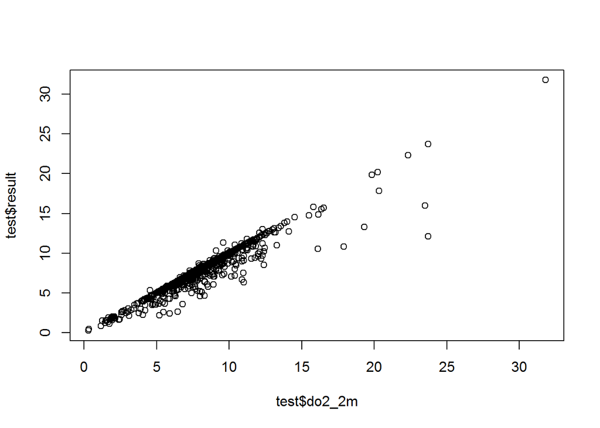

### join the datasets

- convert (if exist) fields RESULT, MDL, RL, and LOQ to numeric
- all files joined
- delete rows for result==NA
- add field duplicate==‘P’; for the 2007 data there are primary and duplicate value; for consistency we’ll add the same field to the 2012 data and set all values to P=primary.
- add “2012_” prefix to all uid
- check that all uid are in ‘nla_samples.csv’ (TRUE)
- uid in ‘nla_samples.csv’ have STATUS==“Target_Sampled”

## QA/QC

- Two qa/qc checks were run on the chem data to make sure the data were assembled correctly.
- sums by parameter for the raw and final datasets were compared and were equal.
- sums by uid for the raw and final datasets were compared and were equal.
- checked sums for the waterchem data only; shows the process worked.

## Data definitions for the NLA2007 and NLA2012 chemistry data

- Below are the data definitions for column names of the chemistry data
- Included are four fields
  - **column_name**: is the column name (field)
  - **name07**: the original name for the parameter in the NLA2007 data (if measured)
  - **name12**: the original name for the parameter in the NLA2012 data (if measured)
  - **description**: a brief description of the field

| column_name | name07 | name12 | description |
| --- | --- | --- | --- |
| batch_id | NA | X_BATCH_ID | Batch ID from lab |
| chem_sample_id | NA | CHEM_SAMPLE_ID | Chemistry Sample ID |
| chem_ship_flag | NA | CHEM_SHIP_FLAG | Chemistry Shipping Flag |
| clear_to_bottom | CLEAR_TO_BOTTOM | CLEAR_TO_BOTTOM | Lake clear to the bottom; if Y (yes) secchi reading should be NA |
| comment | comment | NA | general comment field |
| comment_fld | COMMENT_FLD_CHEM/CHLA | NA | Field Sampling Comments |
| comment_im_chem | COMMENT_IM_CHEM | NA | IM Data Validation Comments |
| comment_lab | COMMENT_LAB_CHEM/CHLA | NA | Laboratory Analysis Comments |
| comment_secchi | COMMENT_SECCHI | NA | Comments and flag explanations for Secchi determination |
| date_analyzed | NA | X_DATE_ANALYZED | Date of sample analysis |
| date_filtered | NA | X_DATE_FILTERED | Date sample filtered |
| date_filtered | DATE_FILTERED | NA | Date Sample was Filtered at Lab |
| date_received | DATE_RECEIVED | X_DATE_RECEIVED | Date sample received by laboratory |
| date_received | DATE_RECEIVED | NA | Date Sample was Received by Lab (from tracking data or WRS lab file ‘2007 Plan 0331081.xls’) |
| datechla | DATECHLA | NA | Date chlorophyll a sample collected |
| datefilt_alert | DATEFILT_ALERT | NA | Sample Filtered at Lab Date (DATE_FILTERED) is AFTER Sample Received by Lab Date (DATE_RECEIVED) (Y/N) |
| day_ship | DAY_SHIP | NA | Number of Days between Sample Collection (DATECHEM) and Sample Filtering at Lab (DATE_FILTERED) |
| dayship_alert | DAYSHIP_ALERT | NA | Number of Days between Sample Collection (DATECHEM) and Sample Filtering at Lab (DATE_FILTERED) Exceeded 2 Days (Y/N) |
| dilution_factor | NA | X_DILUTION_FACTOR | Dilution factor used in chlorophyll calculation |
| duplicate | SAMPLE_CATEGORY | NA | (P)rimary or Field (D)uplicate; original name: SAMPLE_CATEGORY |
| extract | NA | X_EXTRACT | Chlorophyll a in laboratory extract (raw) |
| flag | X_FLAG | X_FLAG | Flag |
| flag_fld_chla | FLAG_FLD_CHLA | NA | Data qualifier (Field Crew) (K=Value could not be determined U=nonstandard measurement Fn=other comment |
| flag_lab_chla | FLAG_LAB_CHLA | NA | Data qualifier (laboratory) (K=Value could not be determined S=value changed [orig. value in parentheses] B=below reporting level [3 æg/L]) |
| flag_secchi | FLAG_SECCHI | NA | Data Qualifier flag for Secchi determination |
| ht | X_HT | X__HOLDING_TIME | Sample holding time; time between sampling and lab analysis (days) |
| ht_alert | X_HT_ALERT | NA | Holding Time Exceeded Limit (Y?N) |
| lab | NA | LAB | Lab name |
| lab_comment | NA | X_LAB_COMMENT | Laboratory comment |
| lab_flag | NA | X_LAB_FLAG | Flag from laboratory |
| lab_id | LAB_ID_CHEM/CHLA | NA | Laboratory sample ID |
| lab_sample_id | NA | X_LAB_SAMPLE_ID | Laboratory Sample ID |
| loq | NA | X_LOQ | Limit of Quantitation (LOQ) associated with sample |
| mdl | NA | X_MDL | Minimum detection limit of analyte |
| nuts_sample_id | NA | NUTS_SAMPLE_ID | Nutrients Sample ID |
| nuts_ship_flag | NA | NUTS_SHIP_FLAG | Nutrients Shipping Flag |
| parameter | X=parameter | X:from:X_RESULT | What was measured |
| qa_flag | NA | X_QA_FLAG | QA flag associated with sample |
| result | X:value | X_RESULT | Measured value for parameter |
| rl | value:X_RL_ALERT | X_RL | Reporting limit |
| rl_alert | X_RL_ALERT | NA | Value Below Reporting Limit |
| sample_depth | SAMPLE_DEPTH | NA | Depth of integrated sample (typically 2 m) |
| sample_id | SAMPLE_ID_CHEM/CHLA | SAMPLE_ID_CHEM | Laboratory Sample Identification Number |
| samplevol | NA | X_SAMPLEVOL | Volume of sample from field (chla) |
| source | nameOfFile | nameOfFile | Source file for data |
| tria_sample_id | NA | TRIA_SAMPLE_ID | Triazine sample ID (atrazine) |
| uid | VISIT_ID | UID | Unique site visit ID; note the year added as prefix (e.g. 007_" or "2012_")“ |
| units | fromDescription | X_UNITS | measurement units |
| usgs_id | USGS_OGRL_laboratory_ID | NA | USGS Sample Identification Number for 2007 Algal Toxin analysis |
| volume_adjust | NA | X_VOLUME_ADJUST | Sample volume adjustment (chla) |

- check that all parameters are in ‘nla_chem_data_paramters.csv’ (TRUE)
- The following table defines the parameters in the chem data
- This table has six fields
  - **parameter**: the name of the chemical analyte or measurement
  - **name07**: the original name for the parameter in the NLA2007 data (if measured)
  - **name12**: the original name for the parameter in the NLA2012 data (if measured)
  - **units07**: the measurement units for the parameter in the NLA2007 data
  - **units12**: the measurement units for the parameter in the NLA2012 data
  - **description**: a brief description of the parameter

[output not shown]

## Save the data

- chem2012 saved as ‘output/nla2012_chem.csv’